# Statistical Inference Course Project

## Part 1: Simulation Exercise

In this project I will investigate the exponential distribution in R and compare it with the Central Limit Theorem. The exponential distribution can be simulated in R with rexp(n, lambda) where lambda is the rate parameter. It is used lambda = 0.2 for all of the simulations. I will investigate the distribution of averages of 40 exponentials.

### 1. Show the sample mean and compare it to the theoretical mean of the distribution.

It is calculated the average of 40 exponentials on 1000 simulations

```r
nsim <- 1000
lambda <- 0.2
n <- 40

# mi is the mean for the simulation i ( 1 <= i <= nsim)
mi = as.data.frame(matrix(nrow=1000, ncol=1))
for (i in 1:nsim) {
   dist = rexp(n,lambda)
   mi[i,1] <- mean(dist)
}

meand <- mean(mi[,1])
```

Sample mean

```r
#The mean of mi
meand
```

```
## [1] 4.998295
```

Theoretical mean of the distribution

```r
#The mean of exponential distribution is 1/lambda
1/lambda
```

```
## [1] 5
```

As we can see, the distribution of the sample mean is centered aproximately at the distribution of the population mean. The sample mean is an estimate of the population mean

### 2. Show how variable the sample is (via variance) and compare it to the theoretical variance of the distribution

Variance of the sample

```r
var(mi[,1])
```

```
## [1] 0.5761118
```

The theoretical variance of the sample mean is (1/lambda)^2/n as the standard deviation is 1/lambda:

```r
tvar <- (1/lambda)^2/n; tvar
```

```
## [1] 0.625
```

Both variances are very close, then the distribution of the sample variance is centered around population variance.

### 3. Show that the distribution is approximately normal

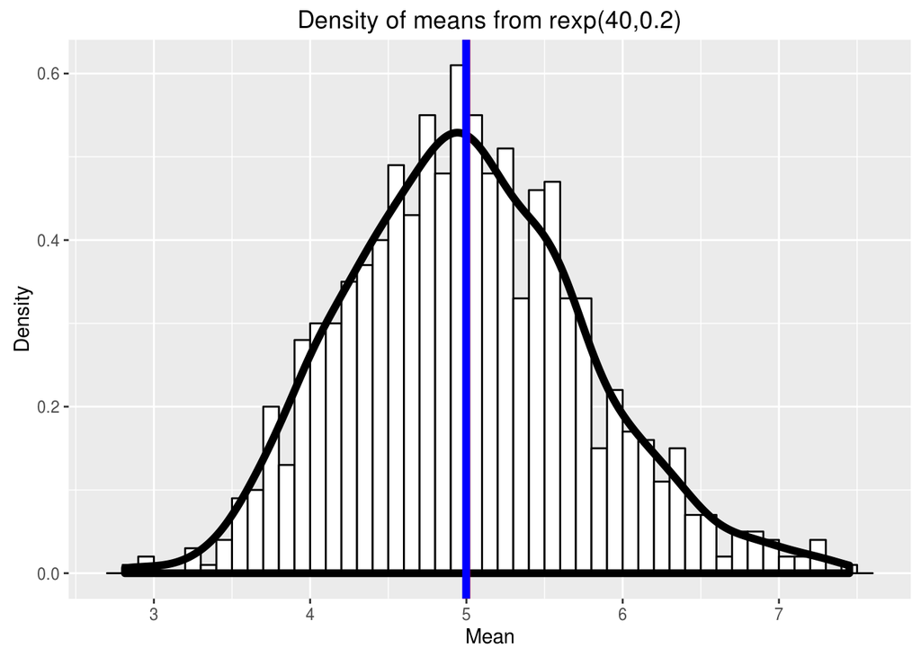

```r
library(ggplot2)

g <- ggplot(mi, aes(x = mi$V1))
g <- g + geom_histogram(fill = "white", binwidth=0.1, aes(y = ..density..), color = "black")
g <- g + geom_density(size = 2)
g <- g + geom_vline(xintercept = 1/lambda, size = 2, color = 'red') # theoretical mean
g <- g + geom_vline(xintercept = meand, size = 2, color = 'blue')          # sample mean
g <- g + labs(title = paste('Density of means from rexp(40,0.2)'))
g <- g + labs(x = "Mean", y = "Density")
g
```

In the figure above, it’s clear that the distribution is approximately normal, since it follows a Gaussian distribution. The red line is the theoretical mean, and the blue one, the sample mean